# Comparing Career Trajectories of Male and Female Soccer Players in FIFA

### Project members

Izzie Lee, 2775355

Lola Xu, 2743123

Kris Son, 2700284

## Introduction

In this project, we examine the research question:  
**Do male and female soccer players peak at the same age, and does their development gap close at the same rate over time?**

We focus on two main questions. First, do male and female players reach their peak at the same age? Second, does the **development gap** — defined as the difference between a player's potential rating and current overall rating — shrink at a similar rate for both genders?

The development gap is a useful measure because it captures how much growth a player still has remaining. This allows us to study career development separately from raw skill level.

The project uses three core variables:

- **Age**
- **Overall rating** : numerical summary of player's total ability & performance
- **Development gap** : potential rating - current overall rating

Age is one of the most important factors in understanding athletic development.

## Data Used: FIFA Players 2016 – 2022

### Women's player datasets

- `female_players_16.csv`
- `female_players_17.csv`
- `female_players_18.csv`
- `female_players_19.csv`
- `female_players_20.csv`
- `female_players_21.csv`
- `female_players_22.csv`

These files contain female player data from FIFA 16 through FIFA 22. Each dataset includes player information such as age, overall rating, and potential rating. For this study, all female-player datasets are combined into one merged female dataset.

### Men's player datasets

- `players_16.csv`
- `players_17.csv`
- `players_18.csv`
- `players_19.csv`
- `players_20.csv`
- `players_21.csv`
- `players_22.csv`

These files contain male player data from FIFA 16 through FIFA 22. Each dataset includes player information such as age, overall rating, and potential rating. For this study, all male-player datasets are combined into one merged male dataset.

## Data Description

For this study, we use 14 FIFA player dataset tables: seven female-player tables (`female_players_16.csv`, `female_players_17.csv`, `female_players_18.csv`, `female_players_19.csv`, `female_players_20.csv`, `female_players_21.csv`, and `female_players_22.csv`) and seven male-player tables (`players_16.csv`, `players_17.csv`, `players_18.csv`, `players_19.csv`, `players_20.csv`, `players_21.csv`, and `players_22.csv`). Each row in every table represents **one player in one FIFA edition**. Therefore, same player may appear in multiple years as separate observations. The female tables contain **248, 299, 317, 299, 345, 345, and 391 observations**, respectively, while the male tables contain **15,623, 17,596, 17,954, 18,085, 18,483, 18,944, and 19,239 observations**, respectively. These datasets include player-level information such as **age, overall rating, potential rating, nationality, club, position, and many other performance-related attributes**. In this project, we merge all female-player tables into one female dataset and all male-player tables into one male dataset, then focus mainly on **age, overall rating, and potential rating** to construct a **development gap** variable (`potential - overall`) for comparing player development patterns across genders.

```python
# Necessary libraries
import pandas as pd
import numpy as np
import matplotlib.pyplot as plt

# Import the data & labeling all dataset
female_player16= pd.read_csv("data/female_players_16.csv")
female_player17= pd.read_csv("data/female_players_17.csv")
female_player18= pd.read_csv("data/female_players_18.csv")
female_player19= pd.read_csv("data/female_players_19.csv")
female_player20= pd.read_csv("data/female_players_20.csv")
female_player21= pd.read_csv("data/female_players_21.csv")
female_player22= pd.read_csv("data/female_players_22.csv")

male_player16= pd.read_csv("data/players_16.csv")
male_player17= pd.read_csv("data/players_17.csv")
male_player18= pd.read_csv("data/players_18.csv")
male_player19= pd.read_csv("data/players_19.csv")
male_player20= pd.read_csv("data/players_20.csv")
male_player21= pd.read_csv("data/players_21.csv")
male_player22= pd.read_csv("data/players_22.csv")
```

```python
# Stack all years into one DataFrame (Using for loops)
# lists to collect age, overall rating, and potential for ALL PLAYERS
ages_f = []
overalls_f = []
potentials_f= []

#Looping for each female data sets
for f in [female_player16, female_player17, female_player18, female_player19, female_player20, female_player21, female_player22]:
    ages_f += list(f["age"]) # collect ages
    overalls_f+= list(f["overall"])# collect overall ratings
    potentials_f += list(f["potential"]) # collect potentials

ages_m = []
overalls_m = []
potentials_m = []

#Looping in the same way as female list for for each male data sets
for m in [male_player16, male_player17, male_player18, male_player19, male_player20, male_player21, male_player22]:
    ages_m += list(m["age"]) # collect ages
    overalls_m+= list(m["overall"]) # collect overall ratings
    potentials_m += list(m["potential"]) # collect potentials

# Create a label (to keep track of gender)
gender_list=[]
for i in range(len(ages_f)) :
    gender_list.append("Female")
for i in range(len(ages_m)):
    gender_list.append("Male")

# Merge all into one DataFrame
# Includes: ge, overall rating, potential, gender
df = pd.DataFrame({"age": ages_f + ages_m, "overall":overalls_f + overalls_m, "potential":potentials_f +potentials_m, "gender":gender_list})
df
```

|  | age | overall | potential | gender |
| --- | --- | --- | --- | --- |
| 0 | 32 | 91 | 91 | Female |
| 1 | 29 | 90 | 90 | Female |
| 2 | 35 | 90 | 90 | Female |
| 3 | 28 | 90 | 90 | Female |
| 4 | 27 | 89 | 89 | Female |
| ... | ... | ... | ... | ... |
| 128163 | 22 | 47 | 52 | Male |
| 128164 | 19 | 47 | 59 | Male |
| 128165 | 21 | 47 | 55 | Male |
| 128166 | 19 | 47 | 60 | Male |
| 128167 | 19 | 47 | 60 | Male |

128168 rows × 4 columns

### Merging Procedures

(refer to the codes above)

In the beginning, we first spilited our dataframe by gender. Then, we labeled each dataset with its corresponding year so that it would be easier to merge the datasets together. In these datasets, our goal was to combine the 7 datasets (2016-2022) for female players together and the 7 datasets (2016-2022) for male players together to compare how they differ throughout the time. We used a list to stack players’ age, overall rating, and potential. Because there were 7 datasets, we used a for loop. As one of the last steps, we created an empty list to put in the entries so that we could separate age, overall, and potential into female and male. The final step was to merge and create the data into one dataframe.

```python
# Split by gender
female_df = pd.DataFrame(df[df["gender"] == "Female"])
male_df = pd.DataFrame(df[df["gender"] == "Male"])

# Cleaning & Filtering
female_counts = female_df.groupby("age")["overall"].count()
male_counts = male_df.groupby("age")["overall"].count()

# Some ages only have a few players, so their averages might not be reliable
# Therefore, We are going to remove ages that have fewer than 5 players
rare_female_ages= []
for age in female_counts.index:
    if female_counts[age]<5:
        rare_female_ages.append(age)

female_df["age"] = female_df["age"].replace(rare_female_ages, np.nan)

#  And, remove NaN values & create a clean version of female dataframe
clean_ages_f = []
clean_overall_f = []
clean_potential_f = []
for i in range(len(female_df)):
    if female_df["age"].values[i] == female_df["age"].values[i]:
        clean_ages_f.append(female_df["age"].values[i])
        clean_overall_f.append(female_df["overall"].values[i])
        clean_potential_f.append(female_df["potential"].values[i])
female_df = pd.DataFrame({"age": clean_ages_f, "overall": clean_overall_f, "potential": clean_potential_f})

# (Same process for male) Identify rare age (within male players)
rare_male_ages = []
for age in male_counts.index:
    if male_counts[age]<5:
        rare_male_ages.append(age)

male_df["age"] = male_df["age"].replace(rare_male_ages,np.nan)

# make a clean version of male Dataframe
clean_ages_m = []
clean_overall_m = []
clean_potential_m = []
for i in range(len(male_df)):
    if male_df["age"].values[i] == male_df["age"].values[i]:
        clean_ages_m.append(male_df["age"].values[i])
        clean_overall_m.append(male_df["overall"].values[i])
        clean_potential_m.append(male_df["potential"].values[i])
male_df = pd.DataFrame({"age": clean_ages_m, "overall": clean_overall_m, "potential": clean_potential_m})
```

### Main Columns: Age, Overall, and Potential

(refer to male_df & female_df, written below)

The key columns in our study are **age, overall, potential** and below are the codes that show the age, overall, potential of male players and the female players. The ultimate goal of our research is to figure out whether female players and male players (playing the same sport, in the same environment) reach their peak at the same age. Other than age, the reason why we chose overall rating and potential is that those two variables are the elements that best define the players' skill and their attractiveness as players.

```python
male_df
```

|  | age | overall | potential |
| --- | --- | --- | --- |
| 0 | 28.0 | 94 | 95 |
| 1 | 30.0 | 93 | 93 |
| 2 | 31.0 | 90 | 90 |
| 3 | 29.0 | 90 | 90 |
| 4 | 28.0 | 90 | 90 |
| ... | ... | ... | ... |
| 125912 | 22.0 | 47 | 52 |
| 125913 | 19.0 | 47 | 59 |
| 125914 | 21.0 | 47 | 55 |
| 125915 | 19.0 | 47 | 60 |
| 125916 | 19.0 | 47 | 60 |

125917 rows × 3 columns

```python
female_df
```

|  | age | overall | potential |
| --- | --- | --- | --- |
| 0 | 32.0 | 91 | 91 |
| 1 | 29.0 | 90 | 90 |
| 2 | 35.0 | 90 | 90 |
| 3 | 28.0 | 90 | 90 |
| 4 | 27.0 | 89 | 89 |
| ... | ... | ... | ... |
| 2235 | 18.0 | 66 | 81 |
| 2236 | 23.0 | 66 | 75 |
| 2237 | 19.0 | 66 | 79 |
| 2238 | 19.0 | 62 | 77 |
| 2239 | 19.0 | 60 | 75 |

2240 rows × 3 columns

### Data Cleaning and Filtering

(refer to the codes above)

|  | dataset | female_peak_age | female_mean_overall | male_peak_age | male_mean_overall |
| --- | --- | --- | --- | --- | --- |
| 0 | FIFA 16-22 | 36.0 | 80.2 | 33.0 | 69.5 |

|  | Age | Female Gap | Male Gap |
| --- | --- | --- | --- |
| 0 | 17 | 18.8 | 17.3 |
| 1 | 22 | 8.2 | 8.0 |
| 2 | 25 | 3.8 | 3.4 |
| 3 | 30 | 0.0 | 0.0 |

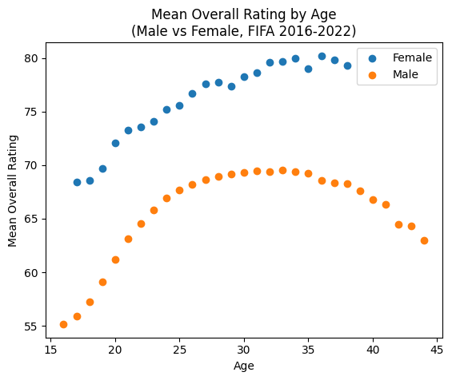

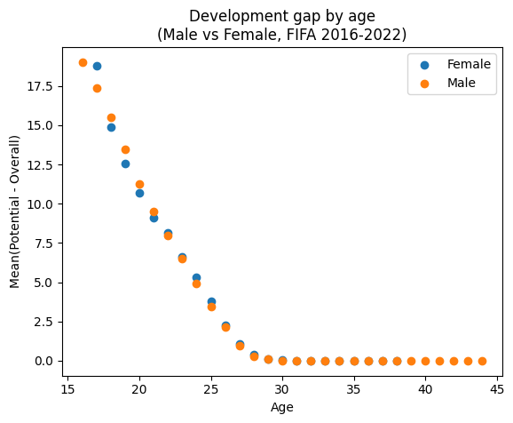

```python
# Find "overall" mean by age (Grouping & Aggregating)
female_overall = female_df.groupby("age")["overall"].mean()
male_overall = male_df.groupby("age")["overall"].mean()


# Create development gap datafrae
# Gap= potential - overall -> how much a player's potential rating is different from their overall rating
female_df["gap"] = female_df["potential"] - female_df["overall"]
male_df["gap"] = male_df["potential"] - male_df["overall"]

# Find the average development gap for each age group
female_gap =female_df.groupby("age")["gap"].mean()
male_gap = male_df.groupby("age")["gap"].mean()

# Find peak age for each gender
# Start with the first age, then check if any other age has a higher mean overall rating
female_peak_age = female_overall.index[0]
for age in female_overall.index:
    if female_overall[age]>female_overall[female_peak_age]:
        female_peak_age = age

#same process for male players
male_peak_age = male_overall.index[0]
for age in male_overall.index:
    if male_overall[age]>male_overall[male_peak_age]:
        male_peak_age=age

# Table 1: Peak Age Summary
female_summary = pd.DataFrame({"dataset": ["FIFA 16-22"], "female_peak_age": [female_peak_age], "female_mean_overall": [round(female_overall[female_peak_age], 1)]})
male_summary = pd.DataFrame({"dataset": ["FIFA 16-22"], "male_peak_age": [male_peak_age], "male_mean_overall": [round(male_overall[male_peak_age], 1)]})

# Merge the female and male summaries into one table to compare
peak_summary = pd.merge(left = female_summary, right = male_summary, how = "left", on = "dataset")
display(peak_summary)

# Table 2: Development Gap Summary by age
# These ages help compare early, middle, and later career patterns
summary_data= {"Age":[], "Female Gap": [], "Male Gap": []}
for a in [17, 22, 25, 30]:
    female_g = female_df[female_df["age"]== a]["gap"].mean()
    male_g = male_df[male_df["age"]== a]["gap"].mean()
    summary_data["Age"].append(a)
    summary_data["Female Gap"].append(round(female_g, 1))
    summary_data["Male Gap"].append(round(male_g, 1))

summary_table = pd.DataFrame(summary_data)
display(summary_table)

# Visualization

# Plots

# plot 1: Mean overall rating by age -> compares how average overall rating changes by age
plt.scatter(x = female_overall.index, y = female_overall.values,label = "Female")
plt.scatter(x = male_overall.index, y = male_overall.values,label = "Male")
plt.xlabel("Age")
plt.ylabel("Mean Overall Rating")
plt.title("Mean Overall Rating by Age\n(Male vs Female, FIFA 2016-2022)")
plt.legend()
plt.show()

#Plot 2: Development gap by age -> shows which age groups may have the most remaining potential
plt.scatter(x= female_gap.index, y= female_gap.values, label = "Female")
plt.scatter(x= male_gap.index, y= male_gap.values, label = "Male")
plt.xlabel("Age")
plt.ylabel("Mean(Potential - Overall)")
plt.title("Development gap by age\n(Male vs Female, FIFA 2016-2022)")
plt.legend()
plt.show()
```

## Results

# Discussion

The primary limitation of our study is that the two research components are incomparable, as one is excessively broad while the other is excessively narrow. This can create a bias and the result that does not fully represent a whole picture. There are thousands of male players from many different levels of professional soccer leagues. On the other hand, women's soccer usually only has the best leagues and the biggest national teams.